# Health Care Expenditure And Disease Prevelance

Stats 331 Final Project Report

Author

Tarini Srikanth, Anshuman Komawar, Garrett Ravatt

In the realm of public health, understanding the complex dynamics between disease prevalence and government spending on healthcare is crucial for effective policy-making and resource allocation. One such area of investigation is the relationship between Malaria prevalence and government expenditure on healthcare. Our analysis focuses on exploring the relationship between Malaria prevalence and government expenditure on healthcare through statistical analysis, visualizations, and predictions.

## Exploring the data

Our data was collected from GapMinder, https://www.gapminder.org/, ‘an independent educational non-proﬁt ﬁghting global misconceptions.’ that provides useful data on a vareity of variables.

We have two datasets we are working with, listed below.

**Malaria Dataset:** Malaria cases per 100,000 residents that are reported. Data: Country (the country pertaining to the cases), Year (the year the cases were reported in), Cases (reported malaria cases per 100,000 people)

**Healthcare Expenditure:** Government health spending of total government spending percentage. Data: Country(the country pertaining to the spending percentage), Year( the year the spending percentages are from), spending (the percentage of total government spending dedicated to health care)

**Our Hypothesis**

With more government dedication and spending towards healthcare, diseases prevalence would decrease. We are focusing specifically on Malaria as the disease, and we believe that with more government dedication towards healthcare, cases of Malaria should decrease, as treatments and cures would benefit from extra government spending, and diseases would be eradicated faster.

## Data Cleaning and organization

For the healthcare expenditure dataset, we did not have to clean up the data, as all the data was present as numbers that represented percentages of government spending.

For the malaria dataset, we did have to clean up the cases variable, as some were in string formats which we then had to convert to number representations. For example, 1k was translated into 1000.

The values of year are spread across multiple columns for both the datasets. For our analysis, we pivoting these tables to be longer to have year be in a single column.

Apart from that, we did not clean the data too much, as we are only focusing on and looking at the cases and spending variables, which we joined into one dataset. Since both datasets contain the country and year columns, we performed an inner join on the data, dropping NA values.

For the Malaria Cases, We had to use the ‘options’ package in R to convert it string formatted numbers like 1.1k to 1100.00. Documentation: https://cran.r-project.org/web/packages/Tplyr/vignettes/options.html

## Data Visualizations

Relationship between Malaria prevelance and government expenditure on healthcare

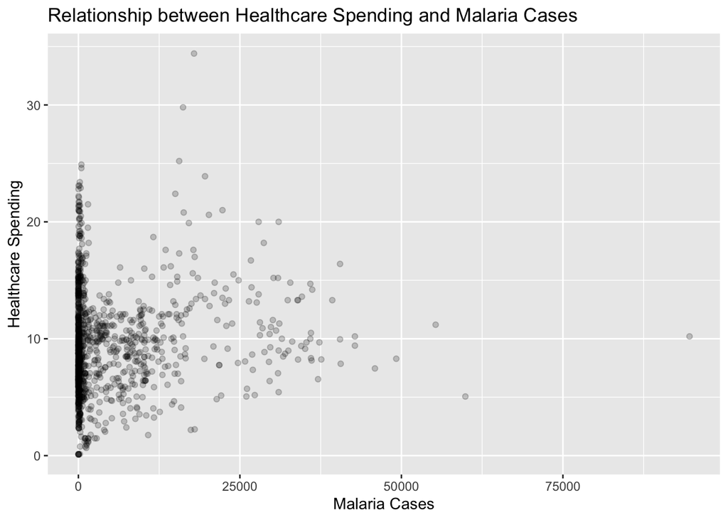

How this relationship has changed over time

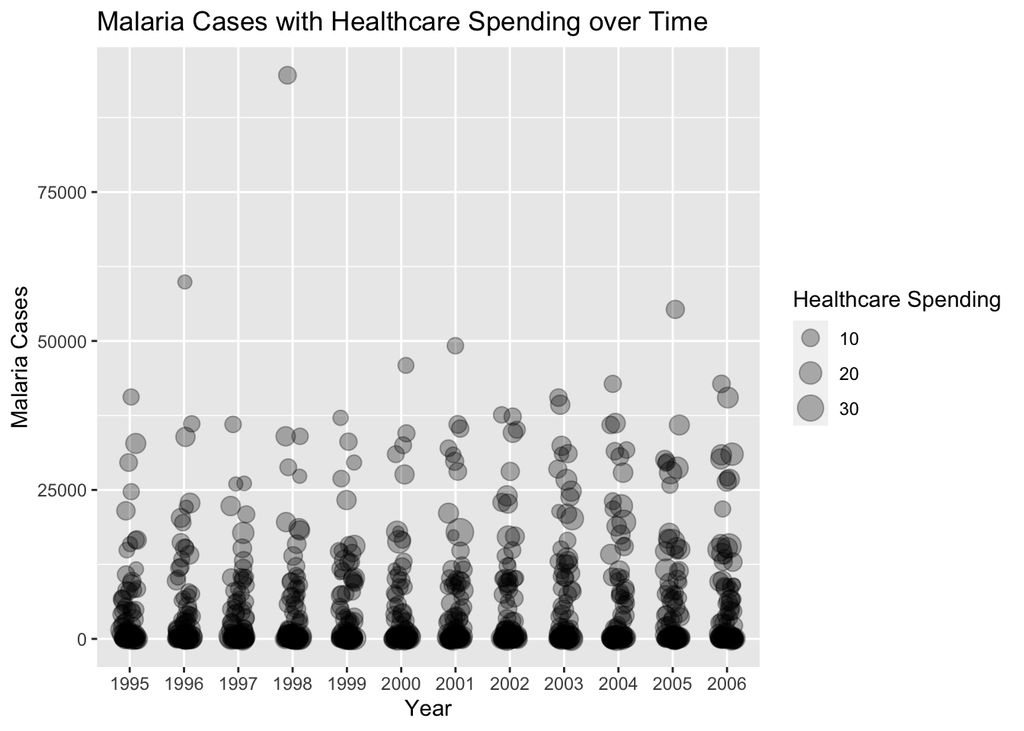

We wanted to focus our area of statistical analysis on countries where the disease prevalence of Malaria was already high to begin with. A lot of countries don’t have a large enough Malaria prevalence for it to be considered dangerous, but still have a lot of government expenditure on healthcare, going towards other areas, which may lead to different conclusions.

To focus on countries with a higher Malaria prevalence, we filtered our data to include only countries whose average cases over all the years was greater than 1000, per 100,000 residents.

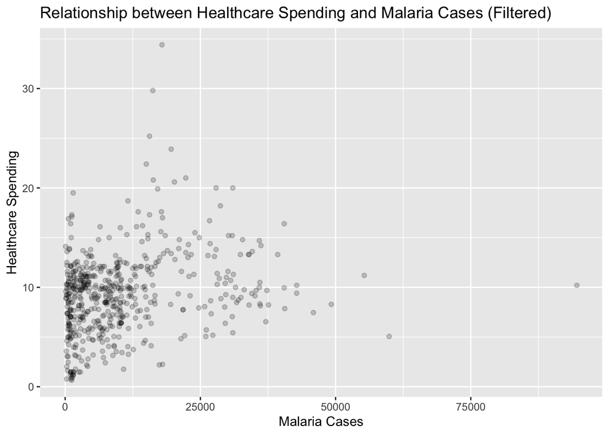

As seen by this plot, there is no clear indication as to whether or not malaria cases are impacted by government expenditure on healthcare.

## Linear Regression

We fit a simple linear regression model for the relationship between the variables we selected.Our response variable is government spending on healthcare, based on our explanatory variable, Malaria disease prevalence.

To perform our linear regression, we summarized our data to have one x value and one y value per country. We did this by taking the average cases across all years.

This Plot shows the relationship between Healthcare Spending and Average Malaria Cases over all the years.

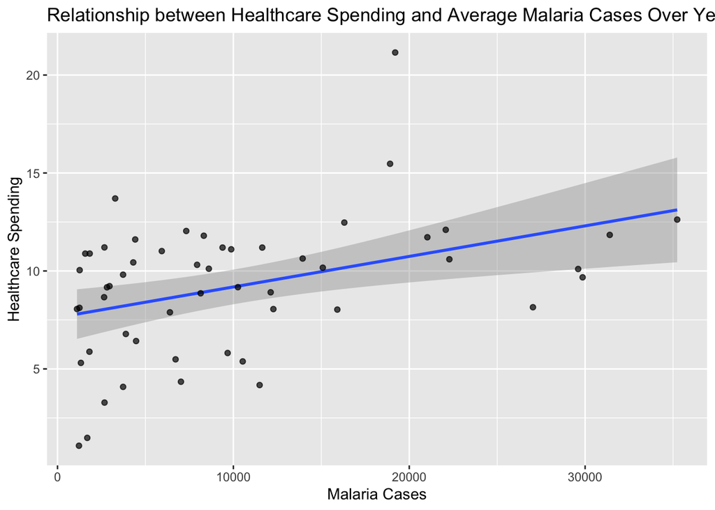

Based on the spending as the response, and the cases as the explanatory, we fit a simple linear regression model.

```
Call:
lm(formula = spending ~ cases, data = countrywise_data)

Residuals:
    Min      1Q  Median      3Q     Max
-6.7362 -2.0763  0.2595  2.1064 10.5327

Coefficients:
              Estimate Std. Error t value           Pr(>|t|)
(Intercept) 7.62522882 0.67123312  11.360 0.0000000000000014 ***
cases       0.00015584 0.00005002   3.116            0.00301 **
---
Signif. codes:  0 '***' 0.001 '**' 0.01 '*' 0.05 '.' 0.1 ' ' 1

Residual standard error: 3.211 on 51 degrees of freedom
Multiple R-squared:  0.1599,    Adjusted R-squared:  0.1434
F-statistic: 9.708 on 1 and 51 DF,  p-value: 0.00301
```

We then calcualted the variance for the response, fitted, and residual values.

| Variance.Type | Variance |
| --- | --- |
| Response Values | 12.037519 |
| Fitted Values | 1.924971 |
| Residuals | 10.112548 |

**The estimated regression model**

spending = 7.625 + 0.00015584 * cases

**The linear regression coefficients.**

The coefficient for the intercept term is 7.625. This represents the estimated average value of the dependent variable (spending) when the independent variable (cases) is zero.

The coefficient for the independent variable (cases) is 0.00015584. This coefficient indicates that for every increase in the number of cases per 100000 people, there is an estimated increase of 0.00015584 percent in the spending variable.

**Analysis of the model fit**

We used linear regression on this model. Linear regression is a statistical modeling technique used to establish a relationship between a dependent variable and one or more independent variables. It assumes a linear relationship, allowing predictions or estimations of the dependent variable based on the values of the independent variables. The goal of linear regression is to find the best-fit line that minimizes the differences between the observed data points and the predicted values

As mentioned before, the fit of the regression model is not quite the best for the given data provided. To get a better fit and more accurate results, we’d have to get more data/ re examine the way we are filtering out the data currently, or try a different model to fit the data on. It could also be the case that Malaria prevelance in these countries and government expenditure on healthcare do not have a linear relationship.

## Visualizing Simulations from the Model

With our simple linear regression, we generated predictions using the predict() function. We then added random errors to the predictions, using the residual standard error estimated from the linear regression model (acquired with sigma()).

Here is the plot of the visualization of the observed data and the simulated data side-by-side.

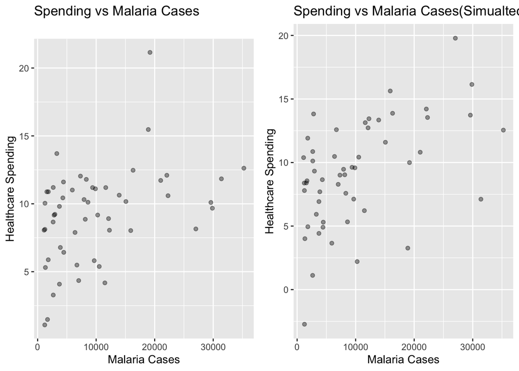

## Generating Multiple Predictive Checks

We generated 1000 simulated datasets that could have been observed if our regression model adequately describes the relationship between the response and explanatory variables.

We regressed the observed dataset against each simulated dataset (e.g. lm(observed ~ simulated)), and kept the R2 from each regression.

These are the distribution of the R2 values from the regressions. The vertical line is our R squared.

```
 num [1:1000] 0.173 0.124 0.259 0.404 0.169 ...
```

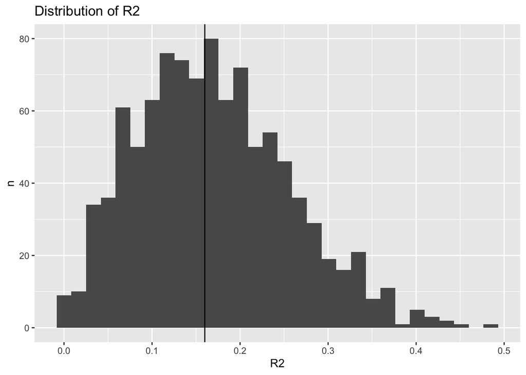

As shown in the values of our plot, the R2 values are relatively low, as reflective in our original predictions. The values range from 0 to 0.5, where most of the values lie in the range from 0.1-0.3. Given that higher R2 values are a reflection how well a model fits, we can safely say that there is not a strong linear relationship between Malaria cases and government spending on healthcare. The model on the generated data was similar to what was observed in our original data, which does not show a clear linear relationship between the two values.

## Extra Credit

```r
library(gganimate)
library(magick)

large_sim <- rnorm(1000)

large_sim_df <- data.frame(ls = rep(large_sim, 10),
                           time = rep(1:10, each = 1000))

r_squared <- median(large_sim_df$ls)

anim <- large_sim_df %>%
  ggplot(aes(x = ls)) +
  geom_histogram(aes(y = ..density..), bins = 30, fill = "#69b3a2", alpha = 0.7, color = "#e9ecef", size = 0.1) +
  geom_vline(aes(xintercept = r_squared)) +
  labs(title = "Distribution of R2", x = "R2", y = "n") +
  transition_time(time) +
  ease_aes('linear')

animated_plot <- animate(anim, renderer = magick_renderer())

image_write(animated_plot, path = "animation.gif")
```